# How can we match you to your dream job?

Martius Eduardo

11/19/2019

##How can we match you to your dream job?

First, we need read the 4 tables.

```r
AvailableCandidates <- read_csv("~/Visual Studio 2017/Projects/VanHackathon/AvailableCandidates.csv")
HiredCandidates <- read_csv("~/Visual Studio 2017/Projects/VanHackathon/HiredCandidates.csv")
HiredJobDetails <- read_csv("~/Visual Studio 2017/Projects/VanHackathon/HiredJobDetails.csv")
JobsToPredict <- read_csv("~/Visual Studio 2017/Projects/VanHackathon/JobsToPredict.csv")
```

With the tables like that, we can’t do anything. So, we need to calculate the SkillsByJob that means how many skills the candidate has for each job. After that we need to calculate how many skills the candidate has (CandidateSkills) and how many skills the jobs needs (JobSkills).

```r
skillsHiredCandidates <- strsplit(HiredCandidates$Skills, ", ")
NewHiredCandidates <- data.frame(UserId = rep(HiredCandidates$UserId, sapply(skillsHiredCandidates, length)), HiredForJobId = rep(HiredCandidates$HiredForJobId, sapply(skillsHiredCandidates, length)), Skills = unlist(skillsHiredCandidates), UsersPosition = rep(HiredCandidates$UsersPosition, sapply(skillsHiredCandidates, length)))

NewHiredCandidates2 <- NewHiredCandidates %>% count(UserId, HiredForJobId, UsersPosition)

skillsHiredJobDetails <- strsplit(HiredJobDetails$Skills, ", ")
NewHiredJobDetails <- data.frame(JobId = rep(HiredJobDetails$JobId, sapply(skillsHiredJobDetails, length)), POSITION = rep(HiredJobDetails$POSITION, sapply(skillsHiredJobDetails, length)), Skills = unlist(skillsHiredJobDetails))

NewHiredJobDetails2 <- NewHiredJobDetails %>% count(JobId, POSITION)

CountSkills <- sqldf("Select nhc.UserId, nhjd.JobId, SUM(CASE WHEN nhc.Skills=nhjd.Skills THEN 1 ELSE 0 END) AS SkillsByJobs, (Select nhc2.n From NewHiredCandidates2 AS nhc2 Where nhc2.UserId = nhc.UserId) As CandidateSkills, (Select nhjd2.n From NewHiredJobDetails2 AS nhjd2 WHere nhjd2.JobId = nhjd.JobId) AS JobSkills
                     From NewHiredCandidates AS nhc
                     Inner Join NewHiredJobDetails AS nhjd
                     Where nhc.HiredForJobId = nhjd.JobId
                     Group by nhc.UserId")

CountSkills <- CountSkills %>% mutate(Class = "Hired")

#----------------------------------------------------------------------------------------

skillsCandidates <- strsplit(AvailableCandidates$Skills, ", ")
NewAvailableCandidates <- data.frame(UserId = rep(AvailableCandidates$UserId, sapply(skillsCandidates, length)), Skills = unlist(skillsCandidates), UsersPosition = rep(AvailableCandidates$UsersPosition, sapply(skillsCandidates, length)), YearsOfExperience = rep(AvailableCandidates$YearsOfExperience, sapply(skillsCandidates, length)), EnglishLevel = rep(AvailableCandidates$EnglishLevel, sapply(skillsCandidates, length)))

NewAvailableCandidates2 <- NewAvailableCandidates %>% count(UserId, UsersPosition, YearsOfExperience, EnglishLevel)
skillsJobsToPredict <- strsplit(JobsToPredict$Skills, ", ")
NewJobsToPredict <- data.frame(JobId = rep(JobsToPredict$JobId, sapply(skillsJobsToPredict, length)), POSITION = rep(JobsToPredict$POSITION, sapply(skillsJobsToPredict, length)), Skills = unlist(skillsJobsToPredict))

NewJobsToPredict2 <- NewJobsToPredict %>% count(JobId, POSITION)

CountSkillsAvailable <- data.frame(UserId = NA, JobId = NA, SkillsByJobs = NA, CandidateSkills = NA, JobSkills = NA) %>% na.omit()

#I used for because R does not support FULL OUTER JOIN and RIGHT JOIN
for (id in JobsToPredict$JobId) {
  CountSkillsAvailable2 <- sqldf(paste(paste("Select nac.UserId, njtp.JobId, SUM(CASE WHEN nac.Skills=njtp.Skills THEN 1 ELSE 0 END) AS SkillsByJobs, (Select nac2.n From NewAvailableCandidates2 AS nac2 Where nac2.UserId = nac.UserId) As CandidateSkills, (Select njtp2.n From NewJobsToPredict2 AS njtp2 WHere njtp2.JobId = njtp.JobId) AS JobSkills
                     From NewAvailableCandidates AS nac, NewJobsToPredict AS njtp
                     Where njtp.JobId = ", id), "Group by nac.UserId"))

  CountSkillsAvailable <- full_join(CountSkillsAvailable, CountSkillsAvailable2, by = c("UserId", "JobId", "SkillsByJobs", "CandidateSkills", "JobSkills"))
}

CountSkillsAvailable <- CountSkillsAvailable %>% mutate(Class = "Not Hired")

#--------------------------------------------------------------------------------------------

CountSkillsTotal <- full_join(CountSkillsAvailable, CountSkills, by = c("UserId", "JobId", "SkillsByJobs", "CandidateSkills", "JobSkills", "Class"))

CountSkillsTotal <- CountSkillsTotal %>% mutate(ClassDummy = if_else(Class == "Hired", 1, 0))

#--------------------------------------------------------------------------------------------
head(CountSkillsTotal, 10)
```

```
##    UserId JobId SkillsByJobs CandidateSkills JobSkills     Class ClassDummy
## 1  533334  3030            0               5         7 Not Hired          0
## 2  533339  3030            1              15         7 Not Hired          0
## 3  533343  3030            3              53         7 Not Hired          0
## 4  533344  3030            0              13         7 Not Hired          0
## 5  533348  3030            0              11         7 Not Hired          0
## 6  533356  3030            0               1         7 Not Hired          0
## 7  533358  3030            0              22         7 Not Hired          0
## 8  533361  3030            1               6         7 Not Hired          0
## 9  533366  3030            0              26         7 Not Hired          0
## 10 533372  3030            0               1         7 Not Hired          0
```

In machine learning we have some tasks, how:

- Classification +Bayes +Rules +Decision Trees
- Grouping +By Density +Prototype based (K-means; K-medoids)
- Association rules +Apriori +FP Growth

We want the 10 bests candidates for each job. Without machine learning algorithm we can tell that: candidates that has more SkillsByJobs is better for the job. We can take top 10 candidates that has more SkillsByJobs. But I created a graphic about this columns to see if I find something.

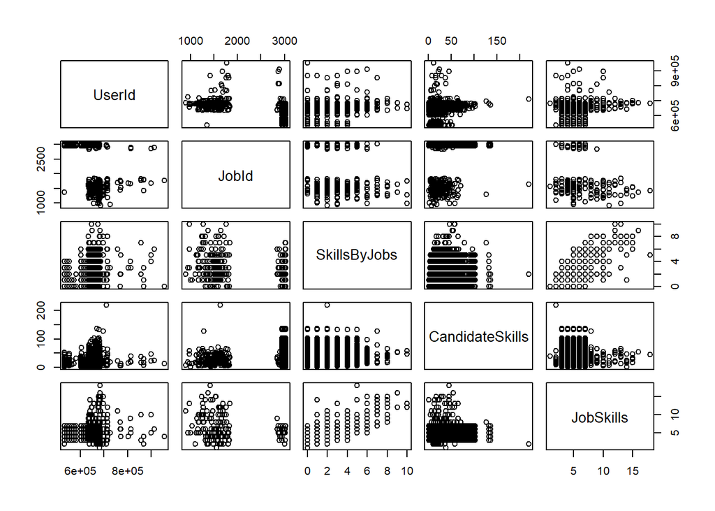

```r
plot(CountSkillsTotal[,1:5])
```

We can see that we can use regression. See SkillsByJobs with JobSkills. If we use just hired candidates we can see that:

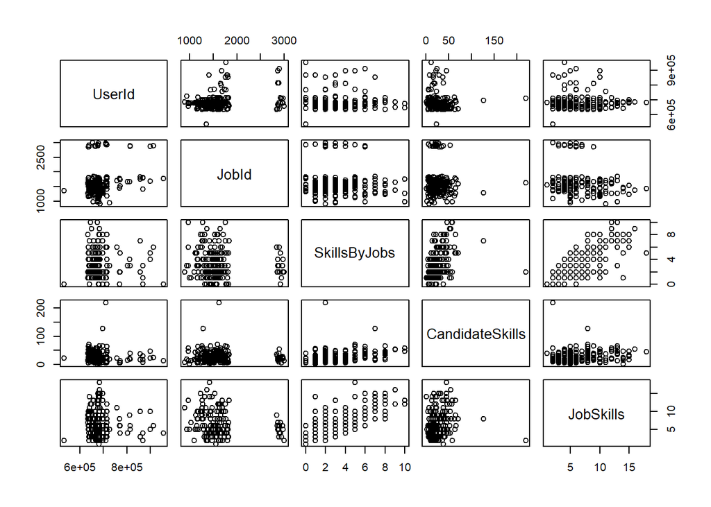

```r
plot(CountSkillsTotal[CountSkillsTotal$Class=="Hired",][,1:5])
```

There is a little difference with SkillsByJobs with CandidateSkills, then I tried to do a regression.

```r
modelo <- lm(ClassDummy ~ SkillsByJobs + CandidateSkills + JobSkills, data = CountSkillsTotal)
summary(modelo)
```

```
##
## Call:
## lm(formula = ClassDummy ~ SkillsByJobs + CandidateSkills + JobSkills,
##     data = CountSkillsTotal)
##
## Residuals:
##      Min       1Q   Median       3Q      Max
## -0.03675 -0.00411  0.00077  0.00180  1.00393
##
## Coefficients:
##                   Estimate Std. Error t value Pr(>|t|)
## (Intercept)     -5.926e-03  6.523e-04  -9.084  < 2e-16 ***
## SkillsByJobs     5.052e-03  1.509e-04  33.471  < 2e-16 ***
## CandidateSkills  3.424e-05  1.268e-05   2.701  0.00692 **
## JobSkills        6.583e-04  1.093e-04   6.021 1.73e-09 ***
## ---
## Signif. codes:  0 '***' 0.001 '**' 0.01 '*' 0.05 '.' 0.1 ' ' 1
##
## Residual standard error: 0.04421 on 100195 degrees of freedom
## Multiple R-squared:  0.01395,    Adjusted R-squared:  0.01392
## F-statistic: 472.5 on 3 and 100195 DF,  p-value: < 2.2e-16
```

```r
CountSkillsRegression <- CountSkillsTotal %>% mutate(y = -0.005926 + 0.005052*SkillsByJobs + 0.00003424*CandidateSkills + 0.0006583*JobSkills)
head(CountSkillsRegression, 10)
```

```
##    UserId JobId SkillsByJobs CandidateSkills JobSkills     Class ClassDummy
## 1  533334  3030            0               5         7 Not Hired          0
## 2  533339  3030            1              15         7 Not Hired          0
## 3  533343  3030            3              53         7 Not Hired          0
## 4  533344  3030            0              13         7 Not Hired          0
## 5  533348  3030            0              11         7 Not Hired          0
## 6  533356  3030            0               1         7 Not Hired          0
## 7  533358  3030            0              22         7 Not Hired          0
## 8  533361  3030            1               6         7 Not Hired          0
## 9  533366  3030            0              26         7 Not Hired          0
## 10 533372  3030            0               1         7 Not Hired          0
##              y
## 1  -0.00114670
## 2   0.00424770
## 3   0.01565282
## 4  -0.00087278
## 5  -0.00094126
## 6  -0.00128366
## 7  -0.00056462
## 8   0.00393954
## 9  -0.00042766
## 10 -0.00128366
```

We can sort by y and take the top 10 candidates for each JobId.

## Conclusion

I think the best way to match you to your job dream is see the SkillsByJobs and JobSkills. If has more SkillsByJobs, then he is a match.